# Midterm 2 Feedback Code

```r
library(tidyverse)
library(janitor)
library(naniar)
library(ggmap)
library(lubridate)
library(shiny)

polar_bears_feedback <-
  read_csv("data/polarBear_serumUreaCreatinine_beaufortChukchi_rode.csv") %>%
  clean_names() %>%
  select(-den_method, -no_cubs, -cub_age) %>%
  filter(age_class %in% c("A", "S")) %>%
  mutate(
    sex = toupper(sex),
    age_class = toupper(age_class)
  ) %>%
  replace_with_na(replace = list(
    mating = "unknown",
    denning = "unknown"
  )) %>%
  mutate(
    capture_date = ymd(capture_date),
    year = year(capture_date),
    un_creat_ratio = (0.466 * urea_nitrogen) / creatinine,
    fasting = case_when(
      un_creat_ratio <= 10 ~ "fasting",
      un_creat_ratio > 10 ~ "not fasting"
    )
  )
```

# Midterm 2 Feedback Code

This file gives short examples of how to strengthen each question without rewriting your full submission. Line references point back to `midterm2.Rmd`.

## Question 1

**What you did well:** You inspected the dataset with `names()` and `summary()`, which meets the main goal of the prompt.

**Improvement idea:** If you want a more compact structure check, `glimpse()` is often easier to read for large tibbles.

**Line references:** See lines 76-80.

```r
glimpse(polar_bears_feedback)
```

```
## Rows: 1,033
## Columns: 14
## $ bear_id        <dbl> 6398, 6280, 6384, 6606, 6520, 20459, 6559, 6160, 20629,…
## $ capture_date   <date> 1985-04-28, 1989-04-11, 1991-04-13, 1992-04-02, 1992-0…
## $ popn           <chr> "SB", "SB", "SB", "SB", "SB", "SB", "SB", "SB", "SB", "…
## $ sex            <chr> "F", "F", "F", "F", "F", "F", "F", "F", "F", "F", "F", …
## $ age_class      <chr> "A", "A", "A", "A", "A", "A", "A", "A", "A", "A", "A", …
## $ mating         <chr> "no", "no", "no", "no", "no", "no", "no", "no", "no", "…
## $ denning        <chr> "yes", "yes", "yes", "yes", "yes", "yes", "yes", "yes",…
## $ lat            <dbl> 70.3833, 70.3333, 70.0167, 70.1833, 70.9000, 70.5136, 6…
## $ long           <dbl> -147.6333, -146.1833, -149.5000, -144.3330, -145.2333, …
## $ urea_nitrogen  <dbl> 12.33, 39.50, 3.00, 4.50, 30.00, 4.00, 18.00, 4.50, 10.…
## $ creatinine     <dbl> 0.57, 0.90, 1.45, 1.60, 0.85, 0.95, 1.10, 0.85, 1.00, 1…
## $ year           <dbl> 1985, 1989, 1991, 1992, 1992, 2000, 2000, 2001, 2003, 2…
## $ un_creat_ratio <dbl> 10.0803158, 20.4522222, 0.9641379, 1.3106250, 16.447058…
## $ fasting        <chr> "not fasting", "not fasting", "fasting", "fasting", "no…
```

## Question 2

**What you did well:** You correctly identified `unknown` as an alternative NA label and used `naniar` tools to explore missingness.

**Improvement idea:** Keep the replacement step and the reporting step clearly separated so the workflow is easier to debug and explain.

**Line references:** See lines 85-99.

```r
polar_bears_feedback %>%
  miss_var_summary()
```

```
## # A tibble: 14 × 3
##    variable       n_miss pct_miss
##    <chr>           <int>    <num>
##  1 mating            601     58.2
##  2 denning           192     18.6
##  3 bear_id             0      0
##  4 capture_date        0      0
##  5 popn                0      0
##  6 sex                 0      0
##  7 age_class           0      0
##  8 lat                 0      0
##  9 long                0      0
## 10 urea_nitrogen       0      0
## 11 creatinine          0      0
## 12 year                0      0
## 13 un_creat_ratio      0      0
## 14 fasting             0      0
```

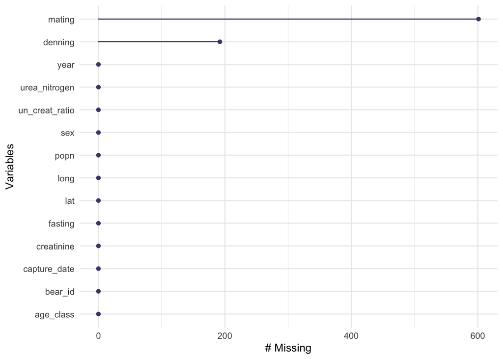

```r
polar_bears_feedback %>%
  gg_miss_var()
```

## Question 3

**What you did well:** Your plot separates the populations and your interpretation on line 112 identifies the main pattern.

**Improvement idea:** Add the missing count table, then let the plot summarize the same result visually.

**Line references:** See lines 104-112.

```r
polar_bears_feedback %>%
  count(popn, sex)
```

```
## # A tibble: 4 × 3
##   popn  sex       n
##   <chr> <chr> <int>
## 1 CS    F       161
## 2 CS    M       135
## 3 SB    F       426
## 4 SB    M       311
```

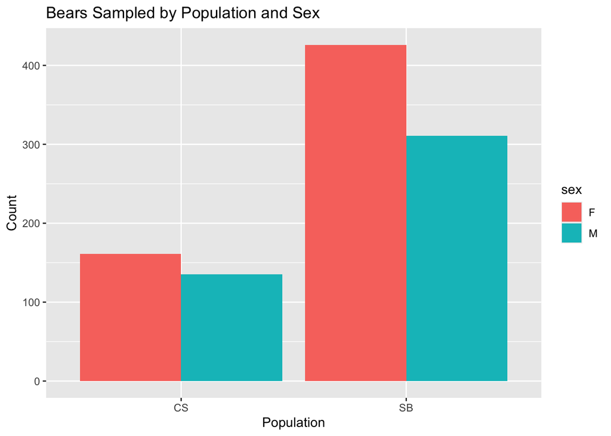

```r
polar_bears_feedback %>%
  count(popn, sex) %>%
  ggplot(aes(x = popn, y = n, fill = sex)) +
  geom_col(position = "dodge") +
  labs(
    title = "Bears Sampled by Population and Sex",
    x = "Population",
    y = "Count"
  )
```

## Question 4

**What you did well:** You recognized that extracting year from `capture_date` was necessary.

**Improvement idea:** This question needs a completed count step and a final line plot. Your commented code on lines 121-142 shows the right direction, but it needs to be finished and run.

**Line references:** See lines 116-142.

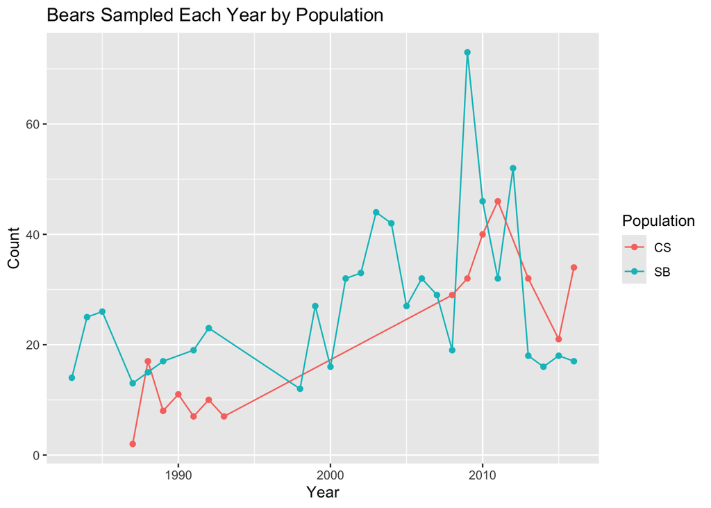

```r
polar_bears_feedback %>%
  count(year, popn) %>%
  ggplot(aes(x = year, y = n, color = popn)) +
  geom_line() +
  geom_point() +
  labs(
    title = "Bears Sampled Each Year by Population",
    x = "Year",
    y = "Count",
    color = "Population"
  )
```

## Question 5

**What you did well:** You found the requested statistics for both variables.

**Improvement idea:** A combined summary makes comparison easier.

**Line references:** See lines 146-160.

```r
polar_bears_feedback %>%
  summarise(
    min_urea = min(urea_nitrogen, na.rm = TRUE),
    median_urea = median(urea_nitrogen, na.rm = TRUE),
    mean_urea = mean(urea_nitrogen, na.rm = TRUE),
    max_urea = max(urea_nitrogen, na.rm = TRUE),
    min_creatinine = min(creatinine, na.rm = TRUE),
    median_creatinine = median(creatinine, na.rm = TRUE),
    mean_creatinine = mean(creatinine, na.rm = TRUE),
    max_creatinine = max(creatinine, na.rm = TRUE)
  )
```

```
## # A tibble: 1 × 8
##   min_urea median_urea mean_urea max_urea min_creatinine median_creatinine
##      <dbl>       <dbl>     <dbl>    <dbl>          <dbl>             <dbl>
## 1        1        10.5      14.9     85.5           0.35              1.05
## # ℹ 2 more variables: mean_creatinine <dbl>, max_creatinine <dbl>
```

## Question 6

**What you did well:** The ratio formula in your answer is correct.

**Improvement idea:** No major changes needed here.

**Line references:** See lines 164-167.

```r
polar_bears_feedback %>%
  select(urea_nitrogen, creatinine, un_creat_ratio) %>%
  slice_head(n = 5)
```

```
## # A tibble: 5 × 3
##   urea_nitrogen creatinine un_creat_ratio
##           <dbl>      <dbl>          <dbl>
## 1          12.3       0.57         10.1
## 2          39.5       0.9          20.5
## 3           3         1.45          0.964
## 4           4.5       1.6           1.31
## 5          30         0.85         16.4
```

## Question 7

**What you did well:** You used `case_when()` correctly and matched the threshold rule.

**Improvement idea:** More descriptive labels make later plots easier to interpret.

**Line references:** See lines 171-175.

```r
polar_bears_feedback %>%
  count(fasting)
```

```
## # A tibble: 2 × 2
##   fasting         n
##   <chr>       <int>
## 1 fasting       767
## 2 not fasting   266
```

## Question 8

**What you did well:** You filtered to fasting bears and made a population-based display.

**Improvement idea:** A line plot is usually the clearest way to show an increase or decrease over time.

**Line references:** See lines 179-187.

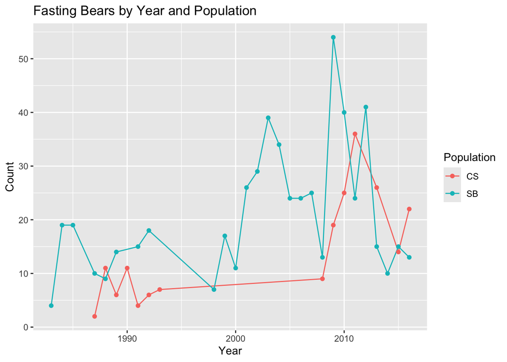

```r
polar_bears_feedback %>%
  filter(fasting == "fasting") %>%
  count(year, popn) %>%
  ggplot(aes(x = year, y = n, color = popn)) +
  geom_line() +
  geom_point() +
  labs(
    title = "Fasting Bears by Year and Population",
    x = "Year",
    y = "Count",
    color = "Population"
  )
```

## Question 9

**What you did well:** You successfully set up the bounding box and used a static map background.

**Improvement idea:** The key fix is mapping point color to `popn` instead of using one fixed color for every bear.

**Line references:** See lines 197-208.

```r
lat <- c(62.46, 72.70)
long <- c(-173.1, -134.8)
bbox <- make_bbox(long, lat, f = 0.10)
map1 <- get_stadiamap(bbox, maptype = "stamen_terrain", zoom = 6)

ggmap(map1) +
  geom_point(
    data = polar_bears_feedback,
    aes(x = long, y = lat, color = popn),
    size = 1.5,
    alpha = 0.8
  ) +
  labs(
    title = "Polar Bear Distribution by Population",
    x = "Longitude",
    y = "Latitude",
    color = "Population"
  )
```

## Question 10

**What you did well:** You identified the needed input choices and kept the chunk non-evaluated so the document could still knit.

**Improvement idea:** This question is incomplete as submitted. A concise working pattern is to let the user choose the fill variable and use a boxplot to show the range of `un_creat_ratio` for each population.

**Line references:** See lines 212-243.

```r
ui <- fluidPage(
  selectInput(
    "fill_var",
    "Select Fill Variable",
    choices = c("sex", "mating", "age_class", "denning", "fasting"),
    selected = "sex"
  ),
  plotOutput("plot", width = "600px", height = "500px")
)

server <- function(input, output, session) {
  output$plot <- renderPlot({
    polar_bears_feedback %>%
      ggplot(aes(x = popn, y = un_creat_ratio, fill = .data[[input$fill_var]])) +
      geom_boxplot() +
      labs(
        title = "Range of Urea Nitrogen to Creatinine Ratio",
        x = "Population",
        y = "UN:Creatinine Ratio",
        fill = "Selected Variable"
      )
  })
}

shinyApp(ui, server)
```

## Next Steps

Your clearest wins came on Questions 1, 5, 6, and 7. To raise this submission most efficiently, focus first on finishing Question 4, revising Question 9 so the map distinguishes populations, and converting Question 10 from a draft into a working app structure.